# Comparative RNASeq Analysis

Thomas Nicholson

14/09/2020

## Overview of sRNA RNAs play a critical role in a wide range of biological functions such as:

- Transcription/Translation
  - rRNA, tRNA, 6sRNA etc.
- Immune response
  - CRISPR-cas
- Gene regulation
  - Riboswitches, sRNAs binding to mRNA etc.
- Virulence

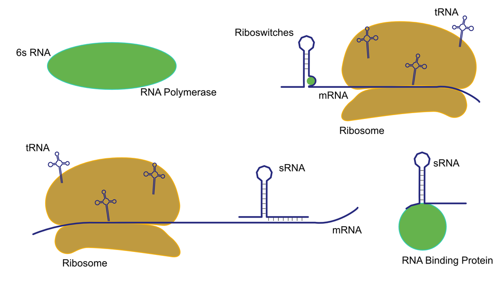

Figure 1. Examples of ncRNAs in bacteria

## Overview of Methods

- Take RNASeq data from multiple genomes
  - 21 strain
  - 11 genera
  - 6 families
- Predict sRNAs based on expressed regions in RNASeq data
  - Use multiple RNASeq datasets for each genome
- Consider a number of different approaches for evaluating the predicted regions
  - Conservation of transcription
  - Conservation of sequence (nhmmer search across genomes from the analysed clade).
  - GC content
  - Covariation observed in sequence alignments (using R-scape)
  - Secondary structure (minimum free energy from RNAAlifold and the Z score of the MFE from alifoldz)
  - Presence of ncRNA motifs (using the rmfam dataset)
- Two control groups will be used
  - Previously annotated sRNAs will be used as a positive control
  - random intergenic sequences of the same lengths as the predicted sRNAs will be used as a negative control

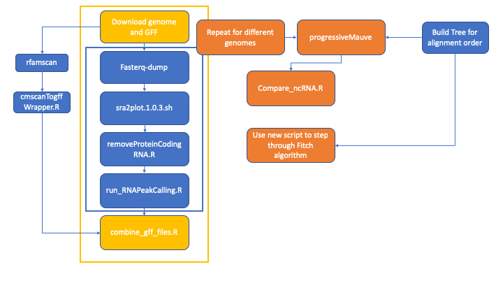

Figure 4. Workflow of methods

## Current Figures

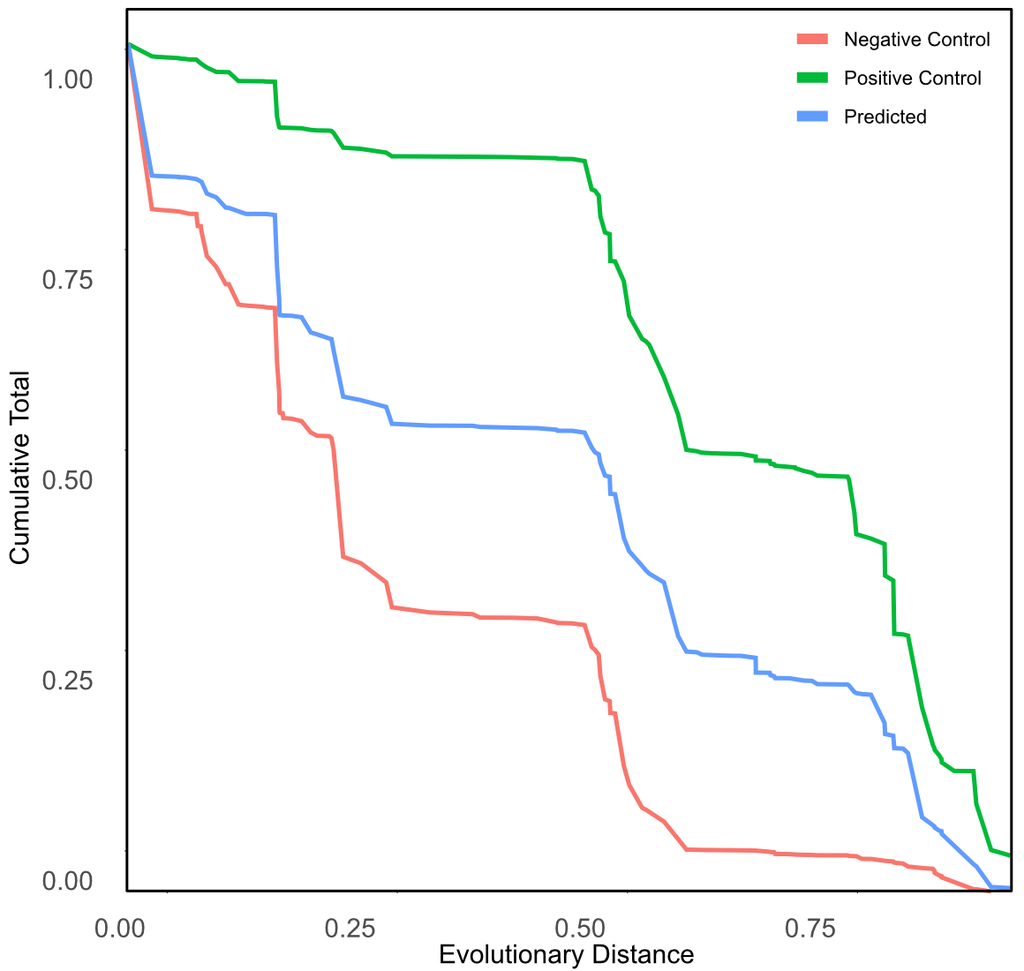

Figure 1. Maximum conserved evolutionary distance per sRNA (cumulative))

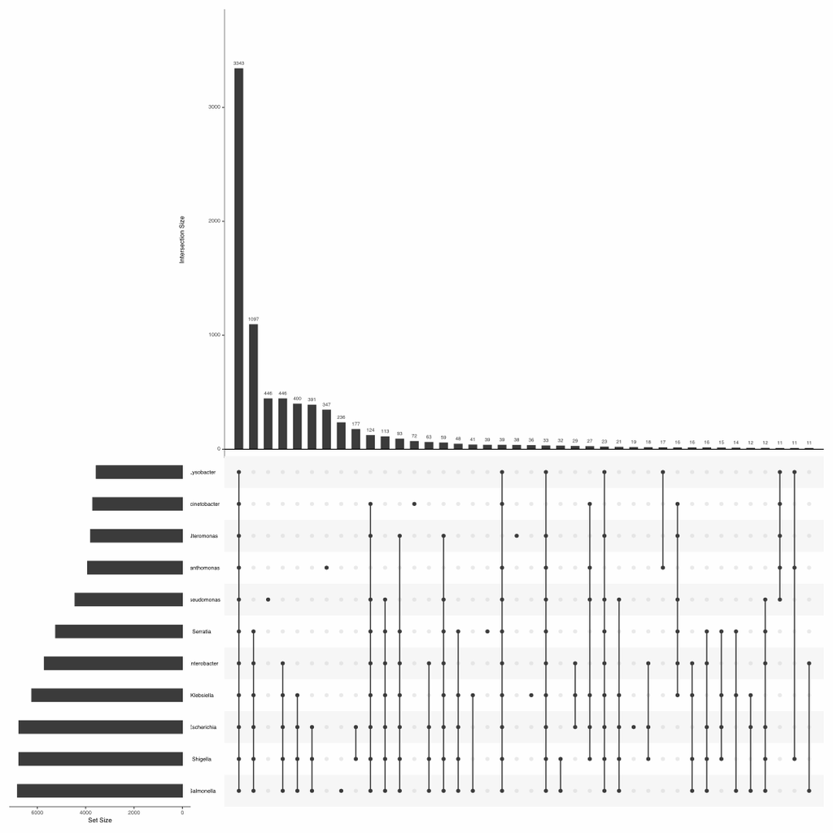

Figure 2. Upset plot for the genera for each sRNA

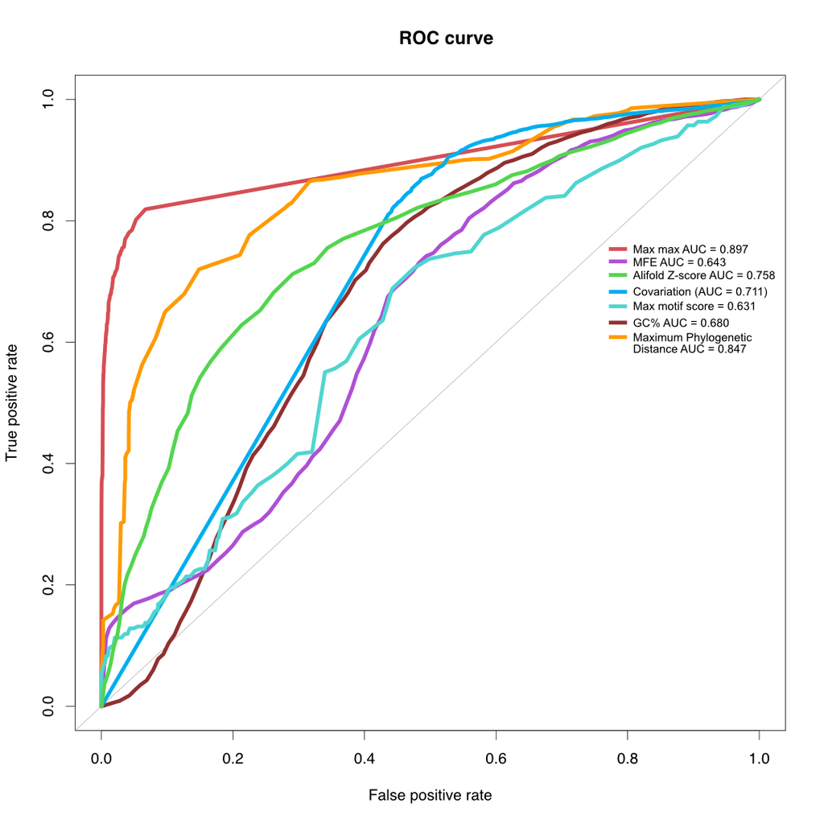

Figure 3. ROC Curves

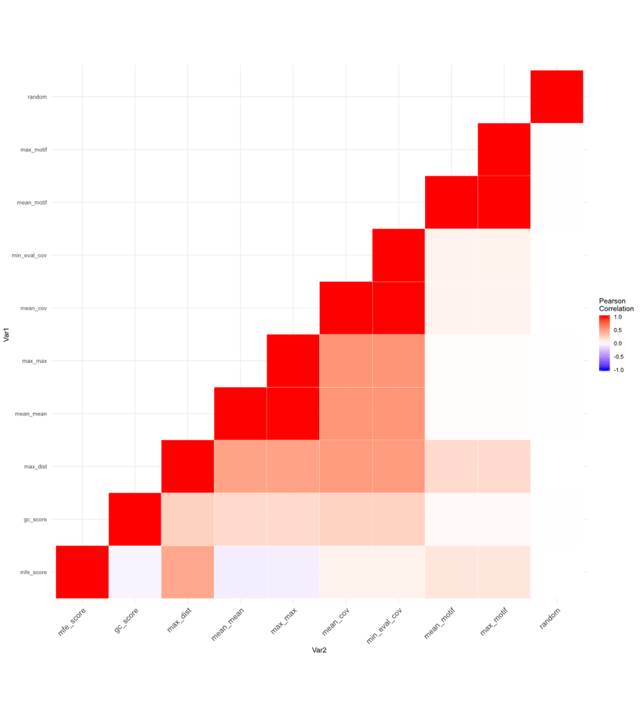

Figure 4. Correlation Matrix for features

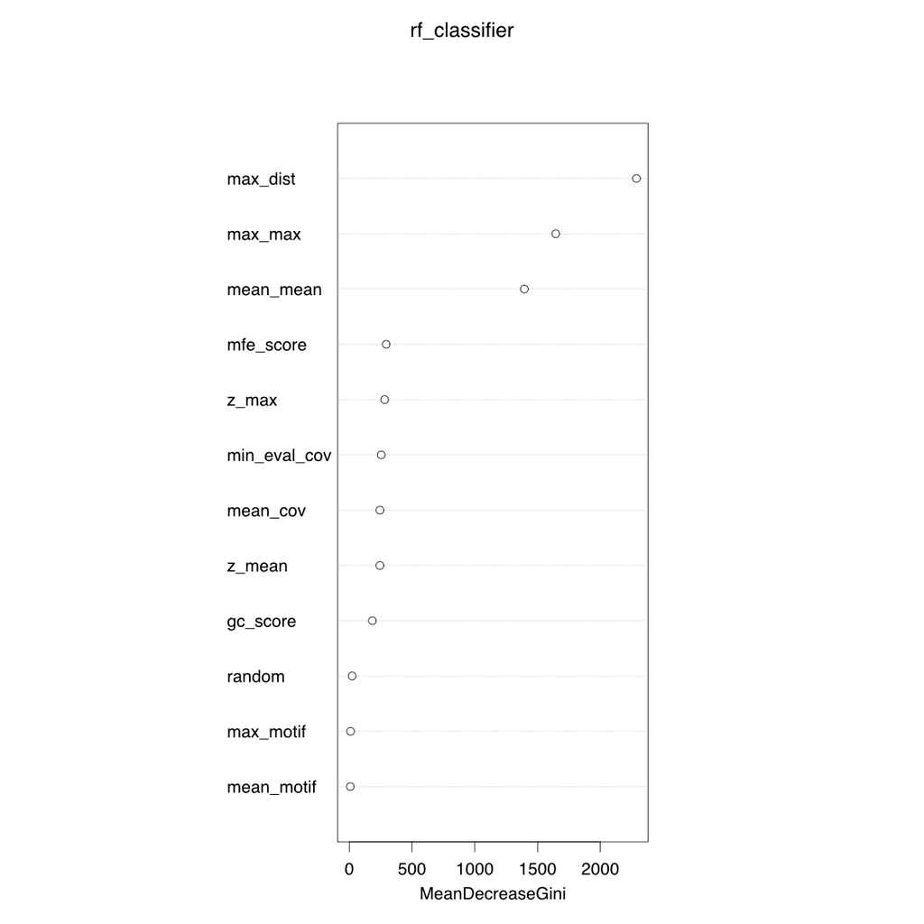

Figure 4. Random forest importance plot

#### Summary of strains used

```r
load("~/bin/r_git/R/r_files/accession_info.Rda")
accession_info <- accession_info %>%
  mutate(strain_short = substr(Strain, start = 1, stop = 30)) %>%
  select(Accession, RNASeq.file.counts, strain_short)
accession_info[1:20,]
```

|  | Accession | RNASeq.file.counts | strain_short |
| --- | --- | --- | --- |
| 1 | GCA_000017745.1 | 2 | Escherichia coli E24377A |
| 2 | GCA_000017765.1 | 8 | Escherichia coli HS |
| 3 | GCA_000017985.1 | 6 | Escherichia coli B str. REL606 |
| 4 | GCA_900186905.1 | 10 | Escherichia coli |
| 5 | GCA_002843685.1 | 10 | Escherichia coli str. K-12 sub |
| 6 | GCA_001559675.1 | 8 | Escherichia coli K-12 |
| 7 | GCA_000497505.1 | 4 | Shigella dysenteriae |
| 8 | GCA_000283715.1 | 8 | Shigella sonnei |
| 9 | GCA_000007405.1 | 8 | Shigella flexneri |
| 10 | GCA_002504125.1 | 5 | Salmonella enterica subsp. ent |

[output cut: 10 more lines]